# DATA MINE PROJECT

Nagarjuna

2024-11-22

#How do factors such as booking cancellation, repeat guest status, number of special requests, Cancellation, and the number of adults influence the Average Daily Rate (ADR) in hotel bookings?

#loading datasets

```r
Hotel_data <- read.csv("Dataset 20-hotel_bookings.csv", stringsAsFactor=FALSE,na.string="")
Hotel_data.cleaned1=Hotel_data
head(Hotel_data.cleaned1,limit=10)
```

```
##          hotel is_canceled lead_time arrival_date_year arrival_date_month
## 1 Resort Hotel           0       342              2015               July
## 2 Resort Hotel           0       737              2015               July
## 3 Resort Hotel           0         7              2015               July
## 4 Resort Hotel           0        13              2015               July
## 5 Resort Hotel           0        14              2015               July
## 6 Resort Hotel           0        14              2015               July
##   arrival_date_week_number arrival_date_day_of_month stays_in_weekend_nights
## 1                       27                         1                       0
## 2                       27                         1                       0
## 3                       27                         1                       0
## 4                       27                         1                       0
## 5                       27                         1                       0
## 6                       27                         1                       0
##   stays_in_week_nights adults children babies meal country market_segment
```

[output cut: 41 more lines]

```r
#Hotel_data.cleaned1[is.na(Hotel_data.cleaned1) | Hotel_data.cleaned1 == "NULL"] = NA
#Hotel_data.cleaned1[is.na(Hotel_data.cleaned1) | Hotel_data.cleaned1 == "NA"] = 0
View(Hotel_data.cleaned1)

Hotel_data.cleaned1$adults <- as.numeric(as.character(Hotel_data.cleaned1$adults))
Hotel_data.cleaned1$babies <- as.numeric(as.character(Hotel_data.cleaned1$babies))
Hotel_data.cleaned1$children <- as.numeric(as.character(Hotel_data.cleaned1$children))
#Hotel_data.cleaned1$total_members <- sum(Hotel_data.cleaned1$adults + Hotel_data.cleaned1$babies + Hotel_data.cleaned1$children, na.rm = TRUE)


#Hotel_data.cleaned1$total_members<-sum[Hotel_data.cleaned1$adults+Hotel_data.cleaned1$babies+Hotel_data.cleaned1$children]
#Hotel_data.cleaned1$babies[is.na(Hotel_data.cleaned1$babies) | Hotel_data.cleaned1$babies == "NA"] = 0
#Hotel_data.cleaned1$children[is.na(Hotel_data.cleaned1$children) | Hotel_data.cleaned1$children == "NA"] = 0
#Hotel_data.cleaned1$adults[is.na(Hotel_data.cleaned1$adults) | Hotel_data.cleaned1$adults == "NA"] = 0
```

#replacing null to NA

```r
Hotel_data.cleaned1[is.na(Hotel_data.cleaned1) | Hotel_data.cleaned1 == "NULL"] = NA

missing_values <- colSums(is.na(Hotel_data.cleaned1))
missing_values
```

```
##                          hotel                    is_canceled
##                              0                              0
##                      lead_time              arrival_date_year
##                              0                              0
##             arrival_date_month       arrival_date_week_number
##                              0                              0
##      arrival_date_day_of_month        stays_in_weekend_nights
##                              0                              0
##           stays_in_week_nights                         adults
##                              0                              0
##                       children                         babies
##                              4                              0
##                           meal                        country
##                              0                            488
##                 market_segment           distribution_channel
##                              0                              0
##              is_repeated_guest         previous_cancellations
##                              0                              0
## previous_bookings_not_canceled             reserved_room_type
##                              0                              0
##             assigned_room_type                booking_changes
##                              0                              0
##                   deposit_type                          agent
##                              0                          16340
##                        company           days_in_waiting_list
##                         112593                              0
##                  customer_type                            adr
##                              0                              0
##    required_car_parking_spaces      total_of_special_requests
##                              0                              0
##             reservation_status        reservation_status_date
##                              0                              0
##                              X                      TOTAL.MEM
##                         119390                              0
```

```r
Hotel_data.cleaned1<- Hotel_data.cleaned1[!duplicated(Hotel_data.cleaned1), ]
str(Hotel_data.cleaned1)
```

```
## 'data.frame':    87396 obs. of  34 variables:
##  $ hotel                         : chr  "Resort Hotel" "Resort Hotel" "Resort Hotel" "Resort Hotel" ...
##  $ is_canceled                   : int  0 0 0 0 0 0 0 1 1 1 ...
##  $ lead_time                     : int  342 737 7 13 14 0 9 85 75 23 ...
##  $ arrival_date_year             : int  2015 2015 2015 2015 2015 2015 2015 2015 2015 2015 ...
##  $ arrival_date_month            : chr  "July" "July" "July" "July" ...
##  $ arrival_date_week_number      : int  27 27 27 27 27 27 27 27 27 27 ...
##  $ arrival_date_day_of_month     : int  1 1 1 1 1 1 1 1 1 1 ...
##  $ stays_in_weekend_nights       : int  0 0 0 0 0 0 0 0 0 0 ...
##  $ stays_in_week_nights          : int  0 0 1 1 2 2 2 3 3 4 ...
##  $ adults                        : num  2 2 1 1 2 2 2 2 2 2 ...
##  $ children                      : num  0 0 0 0 0 0 0 0 0 0 ...
##  $ babies                        : num  0 0 0 0 0 0 0 0 0 0 ...
##  $ meal                          : chr  "BB" "BB" "BB" "BB" ...
##  $ country                       : chr  "PRT" "PRT" "GBR" "GBR" ...
```

[output cut: 20 more lines]

# Descriptive Statistics

```r
mean(Hotel_data.cleaned1$is_canceled) # Mean
```

```
## [1] 0.2748982
```

```r
median(Hotel_data.cleaned1$is_canceled) # Median
```

```
## [1] 0
```

```r
length(Hotel_data.cleaned1$is_canceled) # Number of observations
```

```
## [1] 87396
```

```r
sd(Hotel_data.cleaned1$is_canceled) # Standard deviation
```

```
## [1] 0.4464655
```

```r
summary(Hotel_data.cleaned1$is_canceled)
```

```
##    Min. 1st Qu.  Median    Mean 3rd Qu.    Max.
##  0.0000  0.0000  0.0000  0.2749  1.0000  1.0000
```

# Min-max normalization

```r
mi = min(Hotel_data.cleaned1$is_canceled)
ma = max(Hotel_data.cleaned1$is_canceled)
(minmax.weight = (Hotel_data.cleaned1$is_canceled -
mi)/(ma - mi))
```

[output not shown]

[output cut: 2413 more lines]

# Z-score standarization

```r
m = mean(Hotel_data.cleaned1$is_canceled);
s = sd(Hotel_data.cleaned1$is_canceled)
(z.weight = (Hotel_data.cleaned1$is_canceled - m)/s)
```

[output not shown]

[output cut: 12471 more lines]

```r
#z.weight
```

# Skewness

```r
(3*(mean(Hotel_data.cleaned1$is_canceled) -
median(Hotel_data.cleaned1$is_canceled)))/sd(Hotel_data.cleaned1$is_canceled)
```

```
## [1] 1.847163
```

```r
(3*(mean(z.weight) -
median(z.weight)))/sd(z.weight)
```

```
## [1] 1.847163
```

# Transformations for Normality

```r
sqrt.weight = sqrt(Hotel_data.cleaned1$is_canceled) # Square root
sqrt.weight_skew = (3*(mean(sqrt.weight) - median(sqrt.weight))) / sd(sqrt.weight)
ln.weight = log(Hotel_data.cleaned1$is_canceled) # Natural log
ln.weight_skew = (3*(mean(ln.weight) - median(ln.weight))) / sd(ln.weight)
invsqrt.weight = 1 / sqrt(Hotel_data.cleaned1$is_canceled) # Inverse square root
invsqrt.weight_skew = (3*(mean(invsqrt.weight) - median(invsqrt.weight))) /sd(invsqrt.weight)
```

#checking duplicates

```r
duplicates <- Hotel_data.cleaned1[duplicated(Hotel_data.cleaned1), ]
print(duplicates)
```

```
##  [1] hotel                          is_canceled
##  [3] lead_time                      arrival_date_year
##  [5] arrival_date_month             arrival_date_week_number
##  [7] arrival_date_day_of_month      stays_in_weekend_nights
##  [9] stays_in_week_nights           adults
## [11] children                       babies
## [13] meal                           country
## [15] market_segment                 distribution_channel
## [17] is_repeated_guest              previous_cancellations
## [19] previous_bookings_not_canceled reserved_room_type
## [21] assigned_room_type             booking_changes
## [23] deposit_type                   agent
## [25] company                        days_in_waiting_list
## [27] customer_type                  adr
## [29] required_car_parking_spaces    total_of_special_requests
## [31] reservation_status             reservation_status_date
## [33] X                              TOTAL.MEM
## <0 rows> (or 0-length row.names)
```

#Misclassifications

```r
summary_tables <- list(
  A2 = table(Hotel_data.cleaned1$is_canceled),
 A4 = table(Hotel_data.cleaned1$is_repeated_guest)
)
summary_tables
```

```
## $A2
##
##     0     1
## 63371 24025
##
## $A4
##
##     0     1
## 83981  3415
```

#Plots

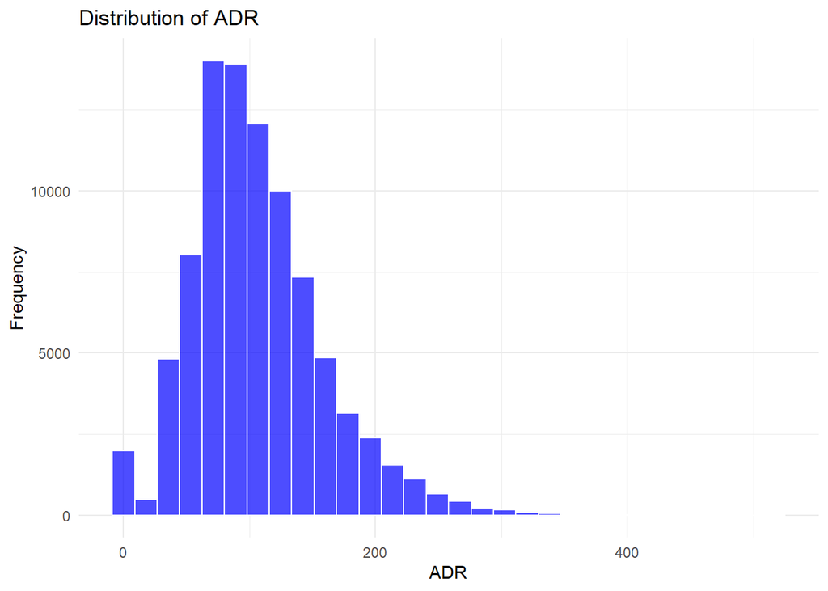

```r
library(readxl)
library(ggplot2)
library(gridExtra)

#install.packages("dplyr")
library(dplyr)
filtered_data <- Hotel_data.cleaned1 %>% filter(adr <= 1000)

# Histogram of ADR
library(ggplot2)
ggplot(filtered_data, aes(x = adr)) +
  geom_histogram(bins = 30, fill = "blue", color = "white", alpha = 0.7) +
  theme_minimal() +
  labs(title = "Distribution of ADR", x = "ADR", y = "Frequency")
```

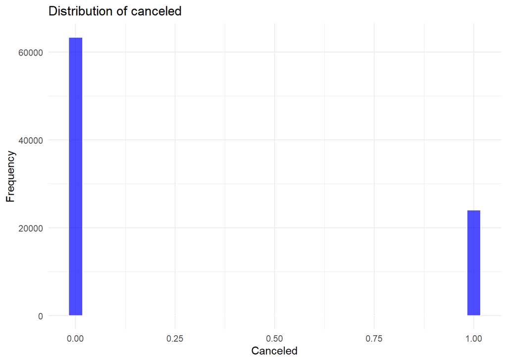

```r
library(ggplot2)
ggplot(filtered_data, aes(x = is_canceled)) +
  geom_histogram(bins = 30, fill = "blue", color = "white", alpha = 0.7) +
  theme_minimal() +
  labs(title = "Distribution of canceled", x = "Canceled", y = "Frequency")
```

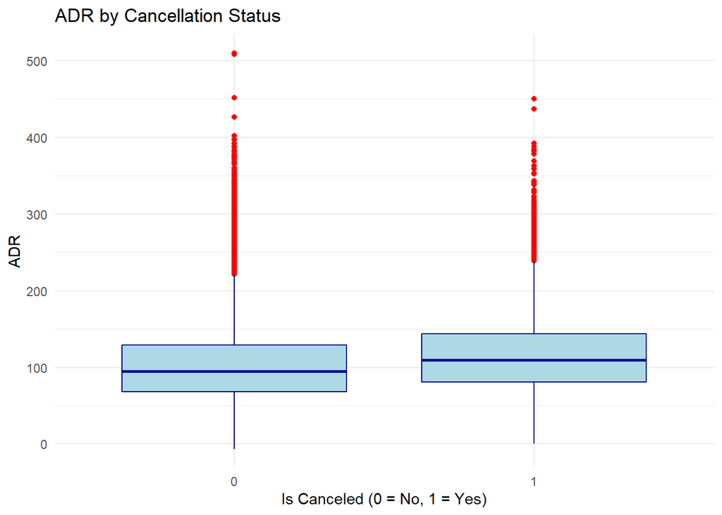

```r
# Box plot of ADR vs IsCanceled
ggplot(filtered_data, aes(x = factor(is_canceled), y = adr)) +
  geom_boxplot(fill = "lightblue", color = "darkblue", outlier.color = "red") +
  theme_minimal() +
  labs(title = "ADR by Cancellation Status", x = "Is Canceled (0 = No, 1 = Yes)", y = "ADR")
```

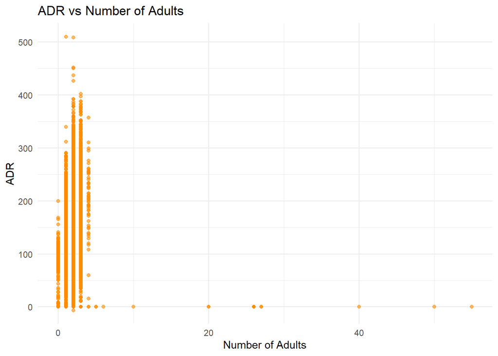

```r
# Scatter plot for ADR vs Adults
ggplot(filtered_data, aes(x = adults, y = adr)) +
  geom_point(alpha = 0.6, color = "darkorange") +
  theme_minimal() +
  labs(title = "ADR vs Number of Adults", x = "Number of Adults", y = "ADR")
```

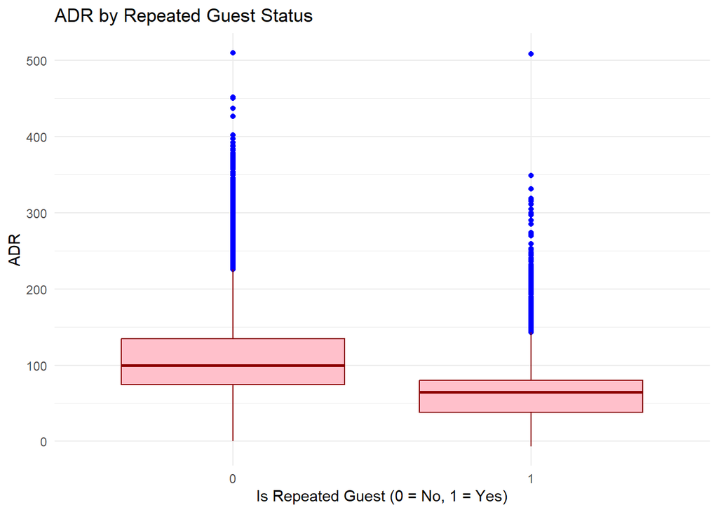

```r
# Box plot for ADR vs IsRepeatedGuest
ggplot(filtered_data, aes(x = factor(is_repeated_guest), y = adr)) +
  geom_boxplot(fill = "pink", color = "darkred", outlier.color = "blue") +
  theme_minimal() +
  labs(title = "ADR by Repeated Guest Status", x = "Is Repeated Guest (0 = No, 1 = Yes)", y = "ADR")
```

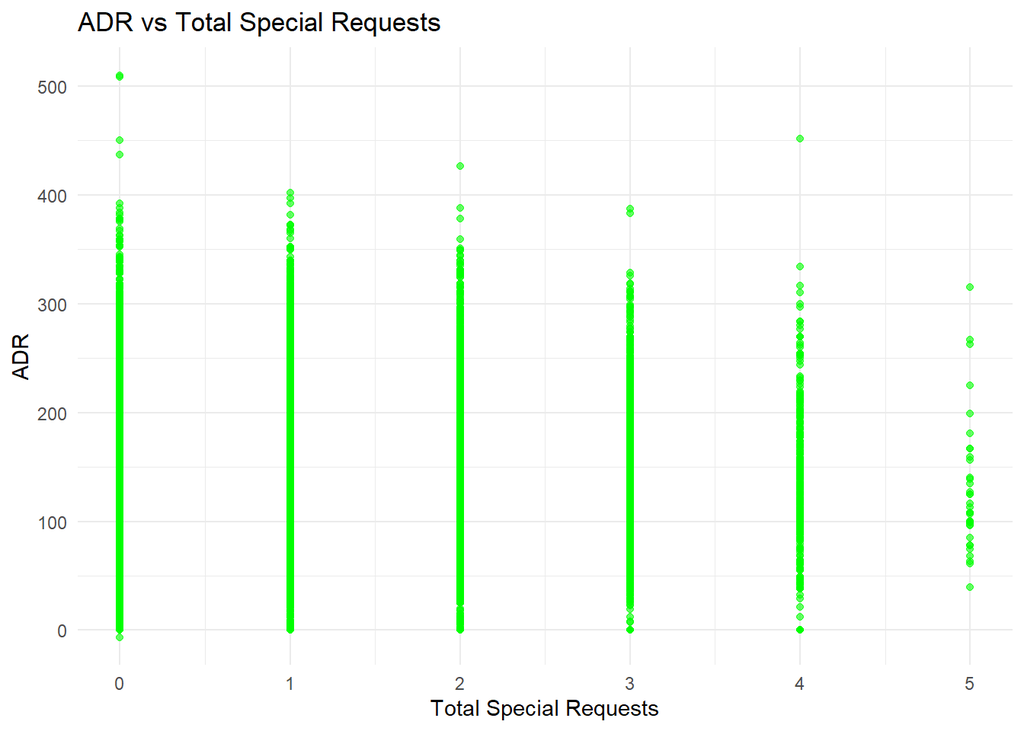

```r
# Scatter plot for ADR vs TotalOfSpecialRequests
ggplot(filtered_data, aes(x = total_of_special_requests, y = adr)) +
  geom_point(alpha = 0.6, color = "green") +
  theme_minimal() +
  labs(title = "ADR vs Total Special Requests", x = "Total Special Requests", y = "ADR")
```

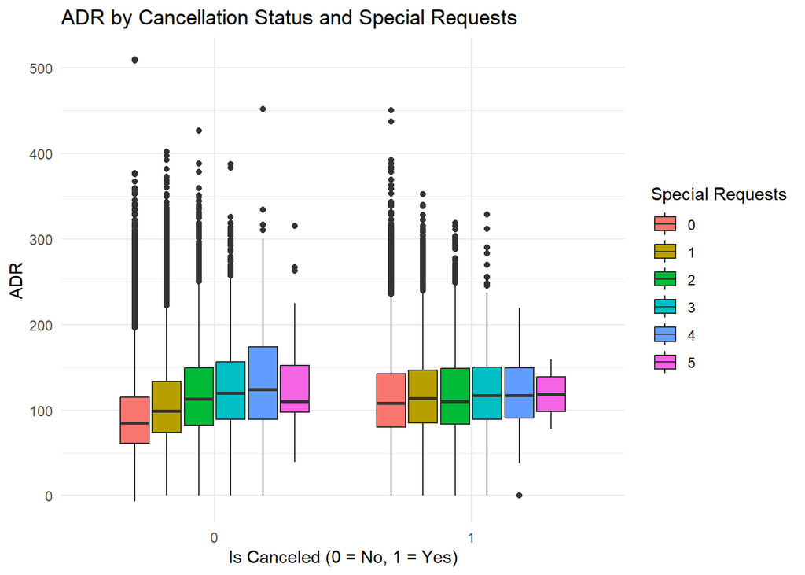

```r
# Box plot for ADR by IsCanceled and Special Requests
ggplot(filtered_data, aes(x = factor(is_canceled), y = adr, fill = factor(total_of_special_requests))) +
  geom_boxplot() +
  theme_minimal() +
  labs(title = "ADR by Cancellation Status and Special Requests",
       x = "Is Canceled (0 = No, 1 = Yes)",
       y = "ADR",
       fill = "Special Requests")
```

(counts = table(Hotel_data.cleaned1$is_canceled, Hotel_data.cleaned1$is_repeated_guest, dnn=c(“is_canceled”)))

summary(Hotel_data.cleaned1$is_canceled)

sum(Hotel_data.cleaned1$is_canceled) / length(Hotel_data.cleaned1$is_canceled)

# Create a bar plot of cancellations and non-cancellations

barplot( table(Hotel_data.cleaned1$is_canceled), ylim = c(0, 100000), main = “Bar Graph of Canceled and Non-canceled Bookings”, col = “lightblue”, xlab = “Booking Status”, ylab = “Count”, names.arg = c(“Not Canceled”, “Canceled”) )

barplot(counts, legend = rownames(counts), col = c(“blue”, “red”), ylim = c(0, 100000), ylab = “Count”, xlab = “ard”, main = “Comparison Bar Chart: canceled Proportions by ard”) box(which = “plot”, lty = “solid”, col=“black”)

addmargins(counts, FUN = sum)

round(prop.table(counts, margin = 2),4)

barplot(counts, col = c(“blue”, “red”), ylim = c(0, 70000), ylab = “Count”, xlab = “Repeated Guest”, main = “Cancelled Count by Repeated Guest”, beside = TRUE) legend(“topright”, c(rownames(counts)), col = c(“blue”, “red”), pch = 15, title = “Cancelled”) box(which = “plot”, lty = “solid”, col=“black”)

summary(Hotel_data.cleaned1$adr)

summary(Hotel_data.cleaned1$TOTAL.MEM)

summary(Hotel_data.cleaned1$stays_in_week_nights)

hist(Hotel_data.cleaned1$stays_in_week_nights, xlim = c(0,10), col = “lightblue”, ylab = “Count”, xlab = ” Calls”, main = “Histogram of Customer Service Calls”)

#categorical_cols <- names(Hotel_data.cleaned1)[sapply(Hotel_data.cleaned1, is.character)] #(Hotel_data.cleaned1[categorical_cols] <- lapply(Hotel_data.cleaned1[categorical_cols], factor)) #View(Hotel_data.cleaned1)

#numerical_cols <- names(Hotel_data.cleaned1)[sapply(Hotel_data.cleaned1, is.numeric)] #(Hotel_data.cleaned1[numerical_cols] <- scale(Hotel_data.cleaned1[numerical_cols]))

```r
library(caret)
set.seed(123)
trainIndex <- createDataPartition(Hotel_data.cleaned1$is_canceled, p = 0.7, list = FALSE)
train_data <- Hotel_data.cleaned1[trainIndex, ]
test_data <- Hotel_data.cleaned1[-trainIndex, ]

table(train_data$is_canceled)/nrow(train_data)
```

```
##
##         0         1
## 0.7260453 0.2739547
```

```r
table(test_data$is_canceled)/nrow(test_data)
```

```
##
##         0         1
## 0.7229003 0.2770997
```

```r
# Convert is_canceled to a factor with two levels
train_data$is_canceled <- as.factor(train_data$is_canceled)
test_data$is_canceled <- as.factor(test_data$is_canceled)

train_control <- trainControl(method = "cv", number = 5)
(model <- train(is_canceled ~ adr+is_repeated_guest+lead_time+TOTAL.MEM+previous_cancellations+previous_bookings_not_canceled+assigned_room_type, data = train_data, method = "glm", family = "binomial", trControl = train_control))
```

```
## Generalized Linear Model
##
## 61178 samples
##     7 predictor
##     2 classes: '0', '1'
##
## No pre-processing
## Resampling: Cross-Validated (5 fold)
## Summary of sample sizes: 48942, 48943, 48943, 48942, 48942
## Resampling results:
##
##   Accuracy   Kappa
##   0.7360815  0.1030453
```

# Re-run the logistic regression model

#log_reg_model <- glm(is_canceled ~ adr+is_repeated_guest+lead_time+TOTAL.MEM+previous_cancellations+previous_bookings_not_canceled+assigned_room_type, data = train_data, family = “binomial”)

```r
log_reg_model1 <- glm(is_canceled ~ adr+is_repeated_guest+lead_time+previous_cancellations+previous_bookings_not_canceled , data = train_data, family = "binomial")
```

#log_reg_model2 <- glm(is_canceled ~ adr+is_repeated_guest+previous_cancellations+previous_bookings_not_canceled+assigned_room_type , data = train_data, family = “binomial”)

#log_reg_model3 <- glm(is_canceled ~ adr+is_repeated_guest , data = train_data, family = “binomial”)

```r
log_reg_model4 <- glm(is_canceled ~ adr+is_repeated_guest+lead_time+assigned_room_type+previous_cancellations+previous_bookings_not_canceled , data = train_data, family = "binomial")
# Check the summary of the model
#summary(log_reg_model)
summary(log_reg_model1)
```

```
##
## Call:
## glm(formula = is_canceled ~ adr + is_repeated_guest + lead_time +
##     previous_cancellations + previous_bookings_not_canceled,
##     family = "binomial", data = train_data)
##
## Coefficients:
##                                  Estimate Std. Error z value Pr(>|z|)
## (Intercept)                    -1.9527740  0.0250784 -77.867   <2e-16 ***
## adr                             0.0056896  0.0001793  31.725   <2e-16 ***
## is_repeated_guest              -1.0195803  0.1049545  -9.714   <2e-16 ***
## lead_time                       0.0041216  0.0001038  39.705   <2e-16 ***
## previous_cancellations          1.8351878  0.0735884  24.939   <2e-16 ***
## previous_bookings_not_canceled -0.3886490  0.0313618 -12.392   <2e-16 ***
## ---
## Signif. codes:  0 '***' 0.001 '**' 0.01 '*' 0.05 '.' 0.1 ' ' 1
##
## (Dispersion parameter for binomial family taken to be 1)
##
##     Null deviance: 71842  on 61177  degrees of freedom
## Residual deviance: 67666  on 61172  degrees of freedom
## AIC: 67678
##
## Number of Fisher Scoring iterations: 7
```

```r
#summary(log_reg_model2)
#summary(log_reg_model3)
summary(log_reg_model4)
```

```
##
## Call:
## glm(formula = is_canceled ~ adr + is_repeated_guest + lead_time +
##     assigned_room_type + previous_cancellations + previous_bookings_not_canceled,
##     family = "binomial", data = train_data)
##
## Coefficients:
##                                  Estimate Std. Error z value Pr(>|z|)
## (Intercept)                    -1.8942193  0.0263931 -71.770  < 2e-16 ***
## adr                             0.0071779  0.0002014  35.633  < 2e-16 ***
## is_repeated_guest              -0.9706906  0.1070764  -9.065  < 2e-16 ***
## lead_time                       0.0041104  0.0001049  39.169  < 2e-16 ***
## assigned_room_typeB            -0.6147766  0.0719772  -8.541  < 2e-16 ***
## assigned_room_typeC            -0.8953445  0.0707068 -12.663  < 2e-16 ***
## assigned_room_typeD            -0.3838029  0.0232541 -16.505  < 2e-16 ***
## assigned_room_typeE            -0.5642035  0.0374669 -15.059  < 2e-16 ***
## assigned_room_typeF            -0.6819380  0.0516536 -13.202  < 2e-16 ***
## assigned_room_typeG            -0.5787590  0.0590466  -9.802  < 2e-16 ***
## assigned_room_typeH            -0.2942545  0.1020387  -2.884  0.00393 **
## assigned_room_typeI            -2.9534893  0.5080153  -5.814 6.11e-09 ***
## assigned_room_typeK            -1.8925779  0.3685157  -5.136 2.81e-07 ***
## assigned_room_typeP            12.4602471 53.4277393   0.233  0.81559
## previous_cancellations          1.7869150  0.0736623  24.258  < 2e-16 ***
## previous_bookings_not_canceled -0.3689231  0.0314994 -11.712  < 2e-16 ***
## ---
## Signif. codes:  0 '***' 0.001 '**' 0.01 '*' 0.05 '.' 0.1 ' ' 1
##
## (Dispersion parameter for binomial family taken to be 1)
##
##     Null deviance: 71842  on 61177  degrees of freedom
## Residual deviance: 66843  on 61162  degrees of freedom
## AIC: 66875
##
## Number of Fisher Scoring iterations: 9
```

#summary(train_data)

levels(train_data$assigned_room_type) levels(test_data$assigned_room_type)

```r
pred_prob <- predict(log_reg_model1, newdata = test_data, type = "response")
pred_class <- ifelse(pred_prob > 0.5, 1, 0)

conf_matrix <- confusionMatrix(as.factor(pred_class), as.factor(test_data$is_canceled))

print(conf_matrix)
```

```
## Confusion Matrix and Statistics
##
##           Reference
## Prediction     0     1
##          0 18626  6666
##          1   327   599
##
##                Accuracy : 0.7333
##                  95% CI : (0.7279, 0.7386)
##     No Information Rate : 0.7229
##     P-Value [Acc > NIR] : 8.494e-05
##
##                   Kappa : 0.0892
##
##  Mcnemar's Test P-Value : < 2.2e-16
##
##             Sensitivity : 0.98275
##             Specificity : 0.08245
##          Pos Pred Value : 0.73644
##          Neg Pred Value : 0.64687
##              Prevalence : 0.72290
##          Detection Rate : 0.71043
##    Detection Prevalence : 0.96468
##       Balanced Accuracy : 0.53260
##
##        'Positive' Class : 0
##
```

```r
library(pROC)
```

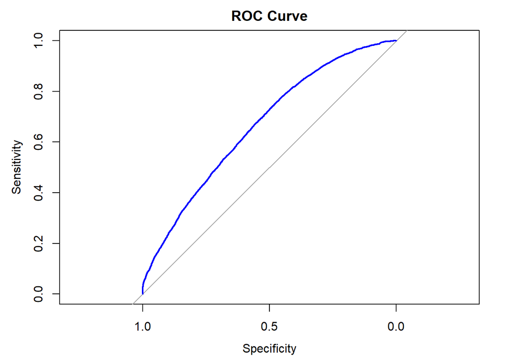

```r
roc_curve <- roc(test_data$is_canceled, pred_prob)
plot(roc_curve, col = "blue", main = "ROC Curve")
```

```r
auc(roc_curve)
```

```
## Area under the curve: 0.6658
```

```r
library(rpart)
tree_model <- rpart(is_canceled ~ adr+is_repeated_guest+lead_time+previous_cancellations+previous_bookings_not_canceled, data = train_data, method = "class")

summary(tree_model)
```

```
## Call:
## rpart(formula = is_canceled ~ adr + is_repeated_guest + lead_time +
##     previous_cancellations + previous_bookings_not_canceled,
##     data = train_data, method = "class")
##   n= 61178
##
##           CP nsplit rel error    xerror        xstd
## 1 0.01840692      0 1.0000000 1.0000000 0.006581803
## 2 0.01000000      2 0.9631862 0.9633055 0.006504483
##
## Variable importance
##                      lead_time         previous_cancellations
##                             61                             26
## previous_bookings_not_canceled              is_repeated_guest
##                              6                              5
##                            adr
##                              2
##
## Node number 1: 61178 observations,    complexity param=0.01840692
##   predicted class=0  expected loss=0.2739547  P(node) =1
##     class counts: 44418 16760
##    probabilities: 0.726 0.274
##   left son=2 (15391 obs) right son=3 (45787 obs)
##   Primary splits:
##       lead_time                      < 11.5   to the left,  improve=1186.7860, (0 missing)
##       previous_cancellations         < 0.5    to the left,  improve= 419.5228, (0 missing)
##       adr                            < 76.015 to the left,  improve= 411.9437, (0 missing)
##       previous_bookings_not_canceled < 0.5    to the right, improve= 258.5099, (0 missing)
##       is_repeated_guest              < 0.5    to the right, improve= 187.5680, (0 missing)
##   Surrogate splits:
##       is_repeated_guest              < 0.5    to the right, agree=0.770, adj=0.087, (0 split)
##       previous_bookings_not_canceled < 0.5    to the right, agree=0.768, adj=0.077, (0 split)
##       adr                            < 35.145 to the left,  agree=0.755, adj=0.028, (0 split)
##       previous_cancellations         < 1.5    to the right, agree=0.750, adj=0.005, (0 split)
##
## Node number 2: 15391 observations
##   predicted class=0  expected loss=0.1040868  P(node) =0.2515774
##     class counts: 13789  1602
##    probabilities: 0.896 0.104
##
```

[output cut: 8 more lines]

```
##       lead_time                      < 36.5   to the left,  improve=101.77500, (0 missing)
##       previous_bookings_not_canceled < 0.5    to the right, improve= 83.15540, (0 missing)
##       is_repeated_guest              < 0.5    to the right, improve= 33.14271, (0 missing)
##   Surrogate splits:
##       previous_bookings_not_canceled < 6.5    to the left,  agree=0.984, adj=0.036, (0 split)
##
## Node number 6: 45004 observations
##   predicted class=0  expected loss=0.3212603  P(node) =0.7356239
##     class counts: 30546 14458
##    probabilities: 0.679 0.321
##
## Node number 7: 783 observations
##   predicted class=1  expected loss=0.1060026  P(node) =0.01279872
##     class counts:    83   700
##    probabilities: 0.106 0.894
```

```r
tree_predictions <- predict(tree_model, newdata = test_data, type = "class")
conf_matrix_tree <- confusionMatrix(tree_predictions, as.factor(test_data$is_canceled))


print(conf_matrix_tree)
```

```
## Confusion Matrix and Statistics
##
##           Reference
## Prediction     0     1
##          0 18905  6982
##          1    48   283
##
##                Accuracy : 0.7319
##                  95% CI : (0.7265, 0.7372)
##     No Information Rate : 0.7229
##     P-Value [Acc > NIR] : 0.0005858
##
##                   Kappa : 0.0516
##
##  Mcnemar's Test P-Value : < 2.2e-16
##
##             Sensitivity : 0.99747
##             Specificity : 0.03895
##          Pos Pred Value : 0.73029
##          Neg Pred Value : 0.85498
##              Prevalence : 0.72290
##          Detection Rate : 0.72107
##    Detection Prevalence : 0.98738
##       Balanced Accuracy : 0.51821
##
##        'Positive' Class : 0
##
```

```r
tree_probs <- predict(tree_model, newdata = test_data, type = "prob")[, 2]
tree_roc <- roc(test_data$is_canceled, tree_probs)
auc(tree_roc)
```

```
## Area under the curve: 0.6234
```

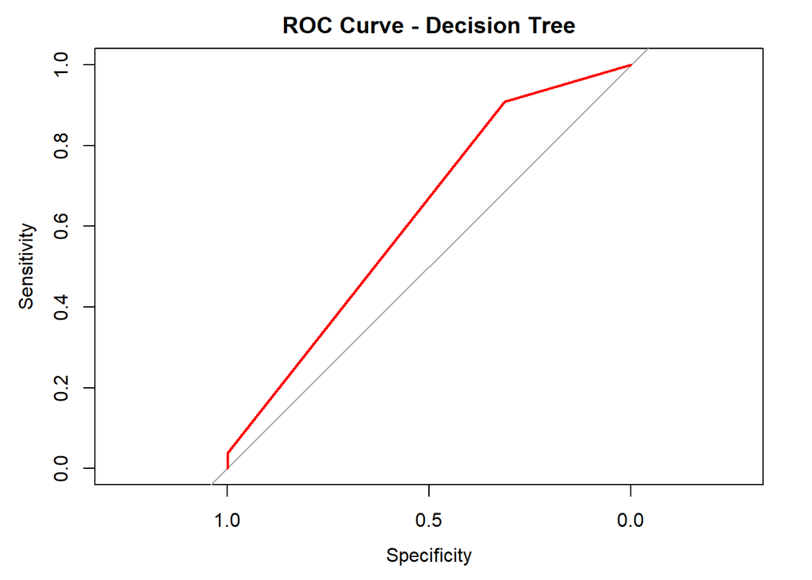

```r
plot(tree_roc, main = "ROC Curve - Decision Tree", col = "red")
```

```r
test_data$assigned_room_type <- factor(test_data$assigned_room_type,
                                        levels = levels(train_data$assigned_room_type))
library(rpart)
tree_model2 <- rpart(is_canceled ~ adr+is_repeated_guest+lead_time+previous_cancellations+previous_bookings_not_canceled+assigned_room_type, data = train_data, method = "class")

summary(tree_model2)
```

```
## Call:
## rpart(formula = is_canceled ~ adr + is_repeated_guest + lead_time +
##     previous_cancellations + previous_bookings_not_canceled +
##     assigned_room_type, data = train_data, method = "class")
##   n= 61178
##
##           CP nsplit rel error    xerror        xstd
## 1 0.01840692      0 1.0000000 1.0000000 0.006581803
## 2 0.01000000      2 0.9631862 0.9637232 0.006505388
##
## Variable importance
##                      lead_time         previous_cancellations
##                             61                             26
## previous_bookings_not_canceled              is_repeated_guest
##                              6                              5
##                            adr
##                              2
##
## Node number 1: 61178 observations,    complexity param=0.01840692
##   predicted class=0  expected loss=0.2739547  P(node) =1
##     class counts: 44418 16760
##    probabilities: 0.726 0.274
##   left son=2 (15391 obs) right son=3 (45787 obs)
##   Primary splits:
##       lead_time                      < 11.5   to the left,  improve=1186.7860, (0 missing)
##       previous_cancellations         < 0.5    to the left,  improve= 419.5228, (0 missing)
##       adr                            < 76.015 to the left,  improve= 411.9437, (0 missing)
##       previous_bookings_not_canceled < 0.5    to the right, improve= 258.5099, (0 missing)
##       is_repeated_guest              < 0.5    to the right, improve= 187.5680, (0 missing)
##   Surrogate splits:
##       is_repeated_guest              < 0.5    to the right,  agree=0.770, adj=0.087, (0 split)
##       previous_bookings_not_canceled < 0.5    to the right,  agree=0.768, adj=0.077, (0 split)
##       adr                            < 35.145 to the left,   agree=0.755, adj=0.028, (0 split)
##       previous_cancellations         < 1.5    to the right,  agree=0.750, adj=0.005, (0 split)
##       assigned_room_type             splits as  RRRRRRRRRRL, agree=0.749, adj=0.000, (0 split)
##
## Node number 2: 15391 observations
##   predicted class=0  expected loss=0.1040868  P(node) =0.2515774
##     class counts: 13789  1602
##    probabilities: 0.896 0.104
```

[output cut: 9 more lines]

```
##       assigned_room_type             splits as  RLLLLLRRLL-, improve=151.9469, (0 missing)
##       lead_time                      < 36.5   to the left,   improve=101.7750, (0 missing)
##       previous_bookings_not_canceled < 0.5    to the right,  improve= 83.1554, (0 missing)
##   Surrogate splits:
##       previous_bookings_not_canceled < 6.5    to the left,  agree=0.984, adj=0.036, (0 split)
##
## Node number 6: 45004 observations
##   predicted class=0  expected loss=0.3212603  P(node) =0.7356239
##     class counts: 30546 14458
##    probabilities: 0.679 0.321
##
## Node number 7: 783 observations
##   predicted class=1  expected loss=0.1060026  P(node) =0.01279872
##     class counts:    83   700
##    probabilities: 0.106 0.894
```

```r
tree_predictions2 <- predict(tree_model2, newdata = test_data, type = "class")
conf_matrix_tree2 <- confusionMatrix(tree_predictions2, as.factor(test_data$is_canceled))

print(conf_matrix_tree)
```

```
## Confusion Matrix and Statistics
##
##           Reference
## Prediction     0     1
##          0 18905  6982
##          1    48   283
##
##                Accuracy : 0.7319
##                  95% CI : (0.7265, 0.7372)
##     No Information Rate : 0.7229
##     P-Value [Acc > NIR] : 0.0005858
##
##                   Kappa : 0.0516
##
##  Mcnemar's Test P-Value : < 2.2e-16
##
##             Sensitivity : 0.99747
##             Specificity : 0.03895
##          Pos Pred Value : 0.73029
##          Neg Pred Value : 0.85498
##              Prevalence : 0.72290
##          Detection Rate : 0.72107
##    Detection Prevalence : 0.98738
##       Balanced Accuracy : 0.51821
##
##        'Positive' Class : 0
##
```

```r
tree_probs2 <- predict(tree_model2, newdata = test_data, type = "prob")[, 2]
tree2_roc <- roc(test_data$is_canceled, tree_probs2)
auc(tree2_roc)
```

```
## Area under the curve: 0.6234
```

```r
library(randomForest)
train_data$is_canceled <- as.factor(train_data$is_canceled)
test_data$is_canceled <- as.factor(test_data$is_canceled)

# Fit the random forest model without the (Intercept)
rf_model <- randomForest(is_canceled ~ adr+is_repeated_guest+lead_time+previous_cancellations+previous_bookings_not_canceled+assigned_room_type, data = train_data, ntree = 500, mtry = 3)


print(rf_model)
```

```
##
## Call:
##  randomForest(formula = is_canceled ~ adr + is_repeated_guest +      lead_time + previous_cancellations + previous_bookings_not_canceled +      assigned_room_type, data = train_data, ntree = 500, mtry = 3)
##                Type of random forest: classification
##                      Number of trees: 500
## No. of variables tried at each split: 3
##
##         OOB estimate of  error rate: 25.63%
## Confusion matrix:
##       0    1 class.error
## 0 43894  524  0.01179702
## 1 15156 1604  0.90429594
```

```r
test_data <- Hotel_data.cleaned1[-trainIndex, ]

rf_predictions <- predict(rf_model, newdata = test_data, type = "class")
conf_matrix_rf <- confusionMatrix(rf_predictions, as.factor(test_data$is_canceled))

print(conf_matrix_rf)
```

```
## Confusion Matrix and Statistics
##
##           Reference
## Prediction     0     1
##          0 18700  6612
##          1   253   653
##
##                Accuracy : 0.7382
##                  95% CI : (0.7328, 0.7435)
##     No Information Rate : 0.7229
##     P-Value [Acc > NIR] : 1.48e-08
##
##                   Kappa : 0.1048
##
##  Mcnemar's Test P-Value : < 2.2e-16
##
##             Sensitivity : 0.98665
##             Specificity : 0.08988
##          Pos Pred Value : 0.73878
##          Neg Pred Value : 0.72075
##              Prevalence : 0.72290
##          Detection Rate : 0.71325
##    Detection Prevalence : 0.96544
##       Balanced Accuracy : 0.53827
##
##        'Positive' Class : 0
##
```

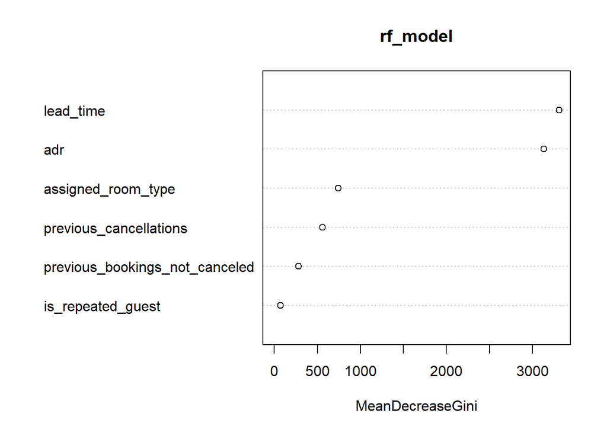

```r
varImpPlot(rf_model)
```

##Interpretation of Logistic Regression and Random Forest Models ##Data Preparation #The dataset Hotel_data.cleaned1 was divided into a training set (70%) and a testing set (30%). The target variable, is_canceled, indicates whether a booking was canceled (1) or not (0). The training data revealed a class imbalance, with about 73% of bookings not canceled and 27% canceled.

#Logistic Regression Model #This model used predictors like average daily rate (ADR), whether the guest was a repeat customer, lead time, and booking history.

#Key Insights from Coefficients:

#ADR (0.0057): As the daily rate increases, cancellations are slightly more likely. #Repeated Guests (-1.0196): Regular customers are less likely to cancel. #Lead Time (0.0041): Longer lead times are linked with more cancellations. #Previous Cancellations (1.8352): Guests who canceled before are much more likely to cancel again. #Previous Bookings Not Canceled (-0.3886): Guests with a history of keeping bookings are less likely to cancel.

#Performance:

#Accuracy: ~73% #Strengths: Very good at identifying non-cancellations (98% sensitivity). #Weaknesses: Struggles to correctly identify cancellations (8% specificity). #ROC-AUC: 0.666 – suggests moderate performance in separating cancellations from non-cancellations.

#Decision Tree Model #Using the same predictors, a decision tree was trained to understand cancellation patterns.

#Key Findings:

#Lead Time and Previous Cancellations were the most influential factors. #Performance:

#Accuracy: ~73% #Strengths: Very strong at identifying non-cancellations (99% sensitivity). #Weaknesses: Very poor at identifying cancellations (4% specificity). #ROC-AUC: 0.623 – slightly weaker discrimination compared to logistic regression.

#Random Forest Model #This ensemble model aimed to improve performance by averaging multiple decision trees.

#Key Insights:

#Accuracy: ~74% – slightly better than logistic regression and decision tree. #Sensitivity: 99%, retaining high accuracy for non-cancellations. #Specificity: Slightly improved at 9%, though still low.

#Conclusion and Recommendations #While all three models provide valuable insights, their tendency to predict non-cancellations more often highlights a key limitation. Specificity remains low, making it difficult to correctly identify cancellations.